# Evolución del rendimiento competitivo en selecciones nacionales: Patrones de goles, ventaja local y cambios temporales (2000-2026)

## 3.4 Pregunta 4: ¿Ha cambiado el promedio de goles a lo largo de los años?

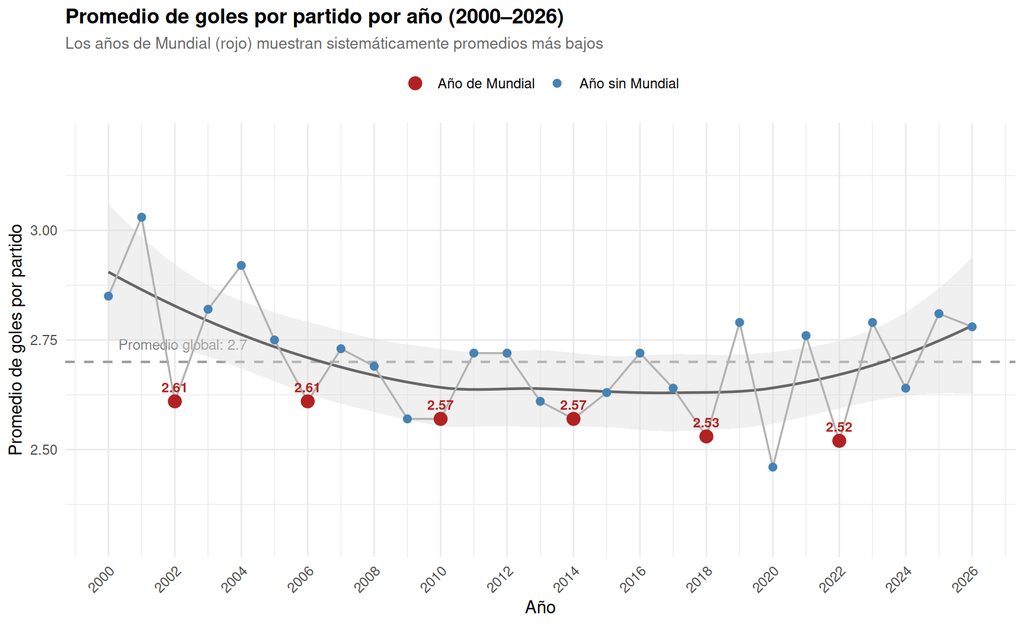

Los años de **Mundial** presentan sistemáticamente promedios de goles por debajo del promedio global de **2.7 goles/partido**, lo que sugiere un juego más cauteloso bajo la presión eliminatoria.

## 3.5 Pregunta 5: ¿Cómo se distribuyen los resultados?

Estadísticas descriptivas

| Métrica | Valor |
| --- | --- |
| Promedio de goles por partido | 2.71 |
| Desviación estándar de goles | 1.92 |
| Promedio de diferencia de goles | 1.63 |
| Desviación estándar de diferencia | 1.69 |
| % partidos con diferencia ≤ 1 gol | 59.1% |

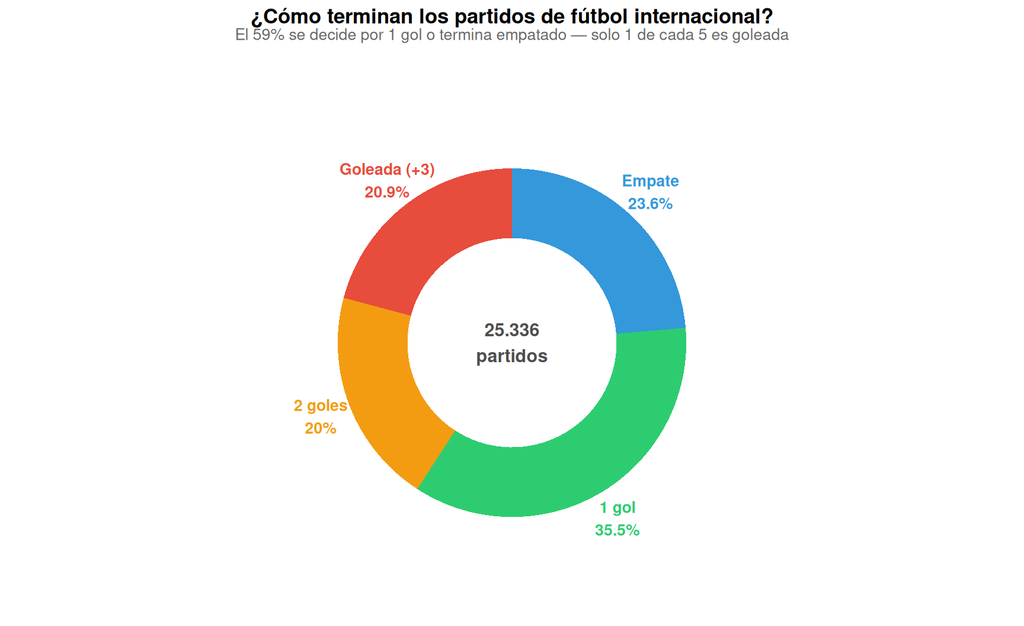

La mayoría de los partidos internacionales son **cerrados**: más de la mitad termina en empate o con 1 gol de diferencia, mientras que solo 1 de cada 5 puede considerarse una goleada.